[figure not shown]

Predicting How Points

End in Tennis

Simon Pang, Xinxiao Jiang, Lindsay Spencer, Jacob Low, Tan Dun Yong

[figure not shown]

Introduction

 AO is Arguably the largest sporting event in Australia

 Point ending type gives insight on player performance

 Tracking system follows ball movements and player movements

 Aim is to construct a classification model to correctly classify outcomes

[figure not shown]

Methodology

 Random Forest & Bagging

 Initial bagging method set a high benchmark (91%)

 Transformation to random forests, returned lower score

 Added in ‘gender’ variable

 Increased the amount of variables, no effect on accuracy

 SVM

 Intuitive method for separating classes

 Not appropriate to multiclass classification, led to lower score

 XGBoost

 Reduces both variance and bias

 Cross-validation to find the best model from XGBoost through lowest logarithmic

loss

 Increased prediction accuracy on outcome (Unforced and Forced)

 Created ‘WINNER’ variable to isolate variables that fulfil the winner criteria

 A better predictor than other methods used

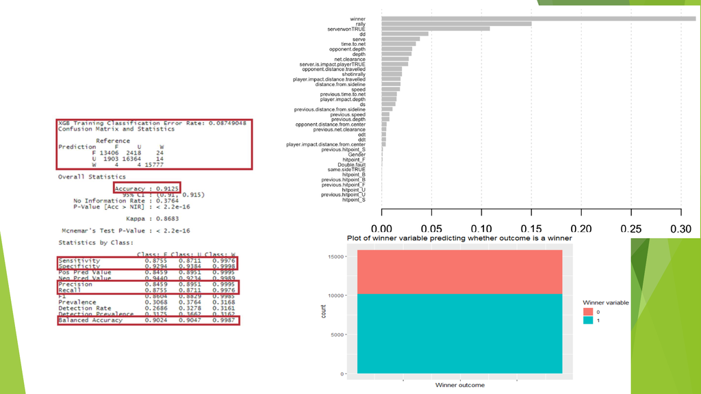

Results & Discussion

 Result

[figure not shown]

Limitations and Conclusion

 XGBoost function returned the best prediction accuracy

 However can not handle categorical variables

 0.92505 in Kaggle

Thanks for listening!

Q&A Time